# Import Packages

Start by importing packages, as usual:

```python
import pandas as pd
import numpy as np
import matplotlib.pyplot as plt
import seaborn as sns
%matplotlib inline
from sklearn.ensemble import RandomForestClassifier
from sklearn.model_selection import train_test_split
from sklearn.tree import DecisionTreeClassifier
from sklearn.metrics import classification_report, confusion_matrix
```

# Load in Data

Then load in data. How about importing the infamous dataset, titanic?

```python
titanic = sns.load_dataset('titanic')
```

# Lets check out the features we are working with.

We have some redundant variables here, so we will get rid of them to avoid multicollinearity.

```python
titanic.head()
```

|  | survived | pclass | sex | age | sibsp | parch | fare | embarked | class | who | adult_male | deck | embark_town | alive | alone |
| --- | --- | --- | --- | --- | --- | --- | --- | --- | --- | --- | --- | --- | --- | --- | --- |
| 0 | 0 | 3 | male | 22.0 | 1 | 0 | 7.2500 | S | Third | man | True | NaN | Southampton | no | False |
| 1 | 1 | 1 | female | 38.0 | 1 | 0 | 71.2833 | C | First | woman | False | C | Cherbourg | yes | False |
| 2 | 1 | 3 | female | 26.0 | 0 | 0 | 7.9250 | S | Third | woman | False | NaN | Southampton | yes | True |
| 3 | 1 | 1 | female | 35.0 | 1 | 0 | 53.1000 | S | First | woman | False | C | Southampton | yes | False |
| 4 | 0 | 3 | male | 35.0 | 0 | 0 | 8.0500 | S | Third | man | True | NaN | Southampton | no | True |

```python
titanic.shape
```

```
(891, 15)
```

# Lets also check out our missing values.

```python
titanic.isnull().sum()
```

```
survived         0
pclass           0
sex              0
age            177
sibsp            0
parch            0
fare             0
embarked         2
class            0
who              0
adult_male       0
deck           688
embark_town      2
alive            0
alone            0
dtype: int64
```

```python
titanic = titanic.drop(['class', 'who', 'adult_male', 'deck', 'alive'], axis=1)
```

How about our "age" column? Should we just drop the missing values and lose 20% of our data? Or are there other methods of handling missing values?

When creating machine learning models, "imputing missing values" is high priority. More data means better models.

Skipping to a few steps forward, here is the results of a decesion tree using the data with missing values in the "age" column just brutely dropped.

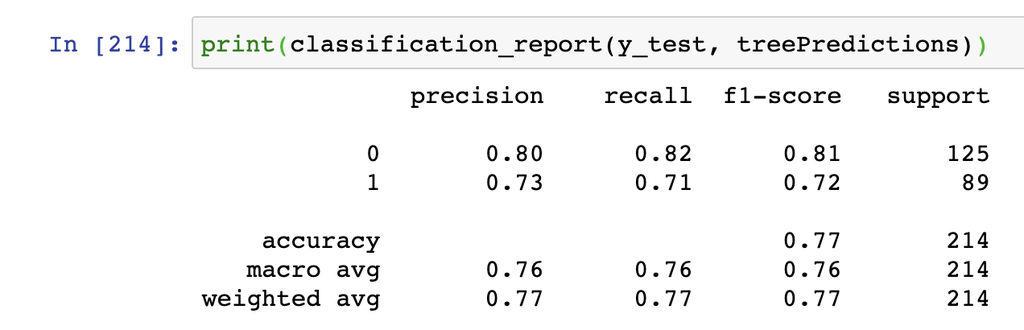

Can we get a better accuracy score than 77% by imputing missing values rather than just dumping rows with NaN's? Well lets give it a shot!

One of the simple approaches for handling missing values for continuous variables is replacing missing values with the mean or median of the variable. We will go one step further and fill the missing values in the "age" column with the average age for each economic class. Perhaps the distribution of age was different for the first, second, and third class?

```python
titanic.groupby('pclass').mean()['age']
```

```
pclass
1    38.233441
2    29.877630
3    25.140620
Name: age, dtype: float64
```

Looks like the average age was significatnly higher for first class. Lets impute the missing values in the "age" column with values above. Its a doosy of a line, but it is handy none the less!

```python
titanic["age"] = titanic.groupby("pclass").transform(lambda x: x.fillna(x.mean()))['age']
```

Now that we have dealt with our NaN's, lets recode our catergorical variables. All predictor variables (our x varibles) passed into any Sci-kit Learn (sklearn) algorithm (classifier or regressor) need to be either integers or floats. Catergorical variables:

- If binary, the groups need to be changed to 0 or 1
- If ordinal, they should numbered in a discrete sequence (i.e. "pclass")
- If non-ordered catergory groups, they will be dummy coded

Tip! You do not need to recode variables of the boolean type, because they are already processed as integer 0 (False) or integer1 (True). How neat!

```python
titanic['sex'] = titanic['sex'].replace(['male', 'female'], [0,1])
```

```python
titanic = pd.get_dummies(titanic)
```

Lets create our dataframe of predictior variables(x) and the series of our target variable(y).

```python
x = titanic.drop('survived', axis=1)
y = titanic['survived'] #one column is a pd.series data type
```

# Train Test Split

As you've done before, you will split the data into training and testing sets. The training set is used to create your initial model, and the testing set is what you will use to gauge the fit of the model.

```python
x_train, x_test, y_train, y_test = train_test_split(x,y, test_size=0.3, random_state=76)
```

# Create Initial Decision Tree

Before you jump into the Random Forest, try a single decision tree. To do this, utilize the DecisionTreeClassifier() function and then fit() the model.

Here is the result you will receive:

```python
decisionTree = DecisionTreeClassifier(random_state=76)
decisionTree.fit(x_train, y_train)
```

```
DecisionTreeClassifier(class_weight=None, criterion='gini', max_depth=None,
                       max_features=None, max_leaf_nodes=None,
                       min_impurity_decrease=0.0, min_impurity_split=None,
                       min_samples_leaf=1, min_samples_split=2,
                       min_weight_fraction_leaf=0.0, presort=False,
                       random_state=76, splitter='best')
```

Are you wondering what all this output means? Well, everything "DecisionTreeClassifier" are the keyword arguments, for ML algorithms in Sklearn, these are called hyperparameters. We will address the most important hyperparameters for decesion trees and random forests on the next page. We will also review an approach to finding optimum values for hyperparameters which can be used for ANY Sckikit Learn machine learning algorithm.

# Assess the Model

Now that the data is fit, the next step is to create a set of predictions and interpret the results. You can start by using the predict() function, and then you'll utilize the same confusion matrix and classification report coding as you did last lesson.

```python
treePredictions = decisionTree.predict(x_test)
```

```python
print(confusion_matrix(y_test, treePredictions))
```

```
[[139  26]
 [ 27  76]]
```

# Examining Precision, Recall, F1-Score, and Accuracy

```python
print(classification_report(y_test, treePredictions))
```

```
              precision    recall  f1-score   support

           0       0.84      0.84      0.84       165
           1       0.75      0.74      0.74       103

    accuracy                           0.80       268
   macro avg       0.79      0.79      0.79       268
weighted avg       0.80      0.80      0.80       268
```

Sweet!!! Our model's accuracy improved by 3% by imputing missing values, instead of just deleting the rows. You may be thinking 3% is not significant, but in a Kaggle competion or a model that goes towards saving a company revenue, the devil is in the details.

And if you find the stats in the confusion matrix confusing, here is what each of the stats represents!!!

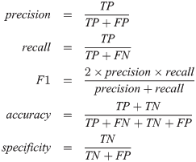